# Discovering the environment

The partical lab is based on the following tools :

- **python** : a general purpose language
  - modern language / very clean / not limited
  - gentle learning curve - easy for beginners
- python **standard library**
  - HUGE
- **jupyter notebook** an interactive layer over the python language
  - a nice GUI of this stuff, also includes **R** and other languages
  - many added convenient utilities added
  - check the `%magic` commands
- **numpy** a library making numeric vectors first class python objects
- **scipy** a library holding *most* standards mathematical and statistical methods
  - other library available.
- **matplotlib** a library for scientific plots

there are also libraries that we will not use, but can be very usefull for data-scientists:

- **pandas** is a very comprehensie data-analysis environment for python - *similar to R*
- **SymPy** is a symbolic environment *similar to Mapple*
- **scikit-learn** a machine-earning envirnment for python

### getting documentation

This is a very important part - you'll find yourself spending more time reading doc than writting code !

Do not hesitate to go through the different help systems - available from here, ( *look at the Help menu of this page, you will recognize the list* )

## Notebook

it is organized in cells, each cell can either contain formatted text ( *this cell!* ), or a python program.

When executed, the result is displayed below the program cell

### commands

- shell type

```python
pwd
```

```
'/Users/mad/Documents/ mad/cours/FT/Fourier_Transform'
```

- python command

there is a slight difficult with python version 2 and 3 co-existing. In practice, there is very little differences, unless you dig deep into the environment. At our level, the following command insures that both versions will behave in an equivalent manner.

```python
from __future__ import print_function, division    # this insures python 2 / python 3 compatibility
```

```python
print( 'this course will last', 1 + 0.5, 'hours')
```

```
this course will last 1.5 hours
```

- python programs

```python
def fibonacci(n):
    "the simplest (and inefficient) definition of the fibonacci series"
    if n == 0 or n == 1:
        f = 1
    else:
        f = fibonacci(n-1) + fibonacci(n-2)
    return f

for i in range(10):
    print (i+1, ':', fibonacci(i+1))
```

```
1 : 1
2 : 2
3 : 3
4 : 5
5 : 8
6 : 13
7 : 21
8 : 34
9 : 55
10 : 89
```

## the python language

python is a simple program, one of its strength lies in all the libraries available - in particular scientific ones (see above)

Some libraries are directly a part of the standard language (web interface, cryptography, data-base, etc. *you name it* ) Other are developped independently, with the standard scientific stack : **numpy, scipy, sympy, matplotlib, pandas** (look at the help menu) or other more specific to a particular domain.

```python
# numpy provides a fast computation of large numerical arrays
import numpy as np     # (here we just give numpy the (standard) nick name np for a lighter source code)

# matplotlib is the graphic library
# matplotlib.pylab is an easy to use utility, a bit reminiscent to matlab graphics
import matplotlib as mpl
import matplotlib.pylab as plt

# %matplotlib is a "magic" command to insert directly the graphics in the web page
%matplotlib inline
```

with these tools we can easily build and display complex functions

```python
x = np.linspace(0,10,1000)                 # 1000 points equi-distant from 0.0 to 10.0
y = np.cos(x)                              # takes the cos() values of all points in x
print('length of vectors, x:',len(x), 'y:',len(y))
print('433th value:', x[432], y[432])      # !!! array indices are from 0 to 999 !!
```

```
length of vectors, x: 1000 y: 1000
433th value: 4.324324324324325 -0.3783976870885793
```

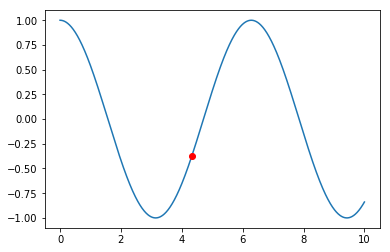

```python
# and plot it - like in Excel !
plt.plot(x,y)                   # whole curve
plt.plot(x[432],y[432], 'ro')   # a set of points   - r is for red   o is for round points
```